# 第20回

- すべてのコードを表示
- すべてのコードを非表示
- ソースコードを表示

作者

J22069 野倉悠正

公開

2025年11月10日

## ログイン機能の実装（Flask経由）

- ログイン情報を`localStrage`に保存していたので、Flask経由でデータベースに保存するように変更。
- 仮想環境で`pip install flask-bcrypt`を実行してライブラリをインストール。

### /backend/app/models.py

**コード**

```python
from . import db, bcrypt

# お祭り情報
class Festivals(db.Model):
   __tablename__ = 'festivals'
   id = db.Column(db.Integer, primary_key=True)    # 内部番号
   name = db.Column(db.String(80), unique=True)    # 名前
   date = db.Column(db.Date)   # 開催日
   location = db.Column(db.String(225))    # 場所
   latitude = db.Column(db.Float)    # 緯度
   longitude = db.Column(db.Float)   # 経度
   attendance = db.Column(db.Integer, default=0)   #動員数
   attend_year = db.Column(db.Integer, default=0)

   def to_dict(self):
       return {
           'id': self.id,
           'name': self.name,
           'date': self.date.strftime('%Y-%m-%d') if self.date else None,
           'location': self.location,
           'latitude': self.latitude,
           'longitude': self.longitude,
           'attendance': self.attendance,
           'attend_year': self.attend_year,
       }

# ユーザーデータ
class User(db.Model):
   __tablename__ = 'users'
   id = db.Column(db.Integer, primary_key=True)
   username = db.Column(db.String(80), unique=True, nullable=False)
   password_hash = db.Column(db.String(128), nullable=False)

   def __init__(self, username, password):
       """コンストラクタ。パスワードをハッシュ化して保存する"""
       self.username = username
       self.password_hash = bcrypt.generate_password_hash(password).decode('utf-8')

   def check_password(self, password):
       """パスワードが一致するかチェックする"""
       return bcrypt.check_password_hash(self.password_hash, password)
```

1. `from . import db, bcrypt`
   - パスワードのハッシュ化を行うための bcrypt をインポートする。
2. `class User(db.Model)`
   - ユーザー情報を格納するための User モデルを定義します。テーブル名は users 。
3. `username = db.Column(...)`
   - ログインに使うユーザー名を保存。`unique=True` を設定して、同じユーザー名が複数登録されないようにする。
4. `password_hash = db.Column(...)`
   - **生のパスワードを直接保存するのではなく**、ハッシュ化された文字列を保存する。これにより、万が一データベースが漏洩しても、ユーザーのパスワードが直接知られることを防ぐ。
5. `__init__(self, username, password)`
   - 新しいユーザーオブジェクトが作成される際に呼び出される。受け取った生のパスワードを `bcrypt.generate_password_hash()` でハッシュ化して `password_hash` に保存。
6. `check_password(self, password)`
   - ログイン時に、入力されたパスワードがDBに保存されているハッシュと一致するかを `bcrypt.check_password_hash()` を使って安全に比較する。

### /backend/app/__init__.py

**コード**

```python
from flask import Flask
from flask_sqlalchemy import SQLAlchemy
from flask_migrate import Migrate
from flask_cors import CORS
from flask_bcrypt import Bcrypt


db = SQLAlchemy()
migrate = Migrate()
bcrypt = Bcrypt()

def create_app():
    """Application-factory function"""
    app = Flask(__name__, instance_relative_config=True)

    # 設定の読み込み
    app.config.from_mapping(
        SQLALCHEMY_DATABASE_URI='sqlite:///fesData.db',
        SQLALCHEMY_TRACK_MODIFICATIONS=False,
    )

    # 拡張機能の初期化
    db.init_app(app)
    migrate.init_app(app, db)
    bcrypt.init_app(app)

    with app.app_context():
        from . import routes
        from . import api_routes
        app.register_blueprint(routes.main_bp)
        app.register_blueprint(api_routes.api_bp)

        # APIルート（/api/で始まる全ルート）に対してCORSを有効にする
        # これにより、React(localhost:3000)からのAPIリクエストが許可される
        CORS(app, resources={r"/api/*": {"origins": "*"}})

        db.create_all()

    return app
```

1. `from flask_bcrypt import Bcrypt`
   - `flask_bcrypt` ライブラリからBcryptクラスをインポートする。
2. `bcrypt = Bcrypt()`
   - `db` や `migrate` と同様に、Bcryptのインスタンスを作成。
3. `bcrypt.init_app(app)`
   - `create_app` ファクトリ関数の中で、作成された`app`オブジェクトを使って`bcrypt`を初期化。

ハッシュ化されたパスワードを含むユーザーデータがUsersテーブルに保存されている様子

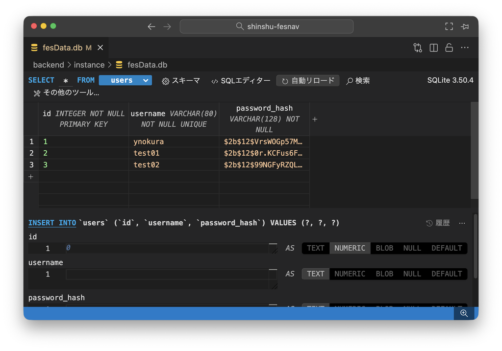

## JWT認証の実装

- ユーザー認証のためにJWT（JSON Web Token）を導入。
- これにより、ログイン後のAPIリクエストが正当なユーザーからのものであることを確認できる。
- 仮想環境で `pip install PyJWT` を実行してライブラリをインストール。

### /backend/app/api_routes.py

**コード**

```python
from flask import Blueprint, request, jsonify, current_app, g
from .models import Festivals, User, UserFavorite, UserDiary, EditLog
from datetime import datetime, timedelta
from . import db
import jwt as pyjwt
import datetime
from functools import wraps

# 'api'という名前でBlueprintを作成
api_bp = Blueprint('api', __name__, url_prefix='/api')

# --- 認証デコレータ ---
def token_required(f):
    @wraps(f)
    def decorated(*args, **kwargs):
        if request.method == 'OPTIONS': # CORSのプリフライトリクエストは認証不要で通過させる
            return jsonify({'message': 'Preflight request successful'}), 200

        token = None
        # リクエストヘッダーからAuthorizationトークンを取得
        if 'Authorization' in request.headers:
            token = request.headers['Authorization'].split(" ")[1] # 'Bearer <token>' の形式を想定

        if not token:
            return jsonify({'message': 'トークンがありません。認証が必要です。'}), 401

        try:
            # トークンをデコードしてユーザー情報を取得
            data = pyjwt.decode(token, current_app.config['SECRET_KEY'], algorithms=["HS256"])
            current_user = User.query.filter_by(id=data['user_id']).first()
            g.current_user = current_user # リクエストコンテキストにユーザー情報を保存
        except pyjwt.ExpiredSignatureError:
            return jsonify({'message': 'トークンの有効期限が切れています。再ログインしてください。'}), 401
        except pyjwt.InvalidTokenError:
            return jsonify({'message': '無効なトークンです。'}), 401

        return f(*args, **kwargs)
    return decorated

# (中略)

# POST /api/login : ログイン
@api_bp.route('/login', methods=['POST'])
def login():
    data = request.get_json()
    username = data.get('username')
    password = data.get('password')

    if not username or not password:
        return jsonify({'error': 'ユーザー名とパスワードを入力してください'}), 400

    user = User.query.filter_by(username=username).first()

    # ユーザーが存在し、かつパスワードが一致するかチェック
    if user and user.check_password(password):
        # JWTトークンを生成
        token = pyjwt.encode({
            'user_id': user.id,
            'exp': datetime.datetime.utcnow() + datetime.timedelta(hours=24) # トークンの有効期限は24時間
        }, current_app.config['SECRET_KEY'], algorithm="HS256")

        # フロントエンドが期待する形式でレスポンスを返す
        return jsonify({
            "token": token,
            "user": { "id": user.id, "username": user.username }
        })

    return jsonify({'error': 'ユーザー名またはパスワードが正しくありません'}), 401
```

1. `import jwt as pyjwt`
   - JWTを扱うためのライブラリをインポートする。`jwt`という名前の別のライブラリとの競合を避けるため、`pyjwt`という別名（エイリアス）を付けている。
2. `token_required` デコレータ
   - 認証が必要なAPIルートに適用するためのデコレータを定義。
   - リクエストヘッダーの `Authorization` からトークンを取得する。
   - `pyjwt.decode()` を使ってトークンを検証。成功すれば、リクエストコンテキスト(`g`)にユーザー情報を保存する。
   - トークンの有効期限切れ(`ExpiredSignatureError`)や不正なトークン(`InvalidTokenError`)などの例外を処理し、適切なエラーメッセージを返す。
3. `login` ルートの変更
   - ユーザー名とパスワードの検証に成功した場合、`pyjwt.encode()` を使ってJWTトークンを生成する。
   - トークンには、ペイロードとしてユーザーIDと有効期限（ここでは24時間）が含まれる。
   - 生成したトークンをフロントエンドに返す。

ローカルストレージにトークンが保存されている様子

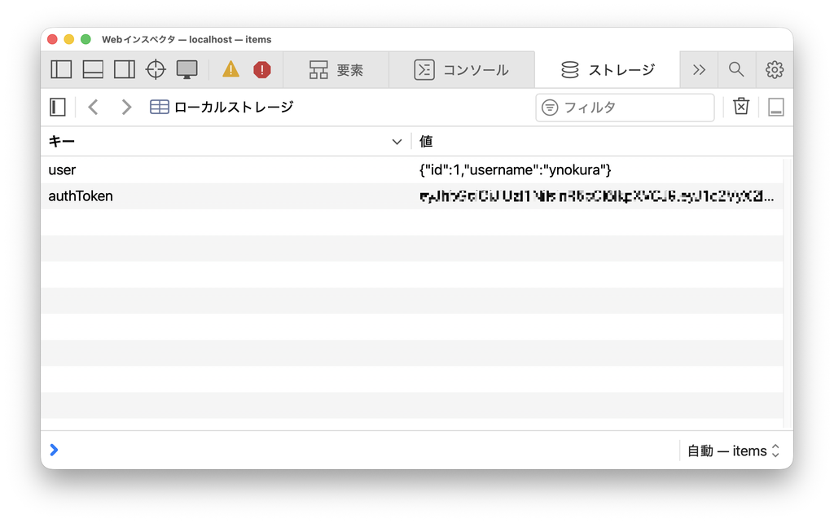

## 次回以降の改善

### 新規登録ページの拡張

現状の新規登録ページ

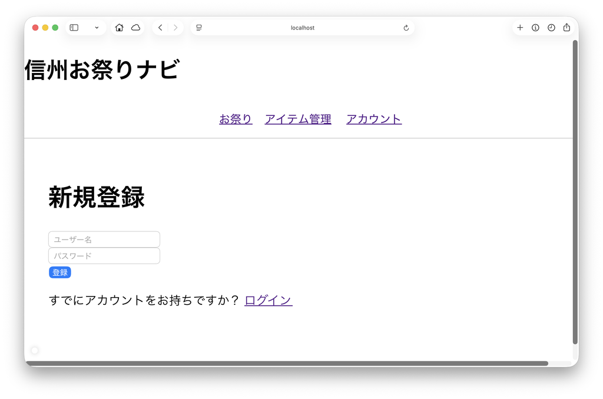

- セキュリティ認証機能の実装（[reCAPTCHA](https://developers.google.com/recaptcha?hl=ja)や[Cloudflare Turnstile](https://www.cloudflare.com/ja-jp/application-services/products/turnstile/) など）
- メールアドレスフィールドの追加（→パスワードリセット）
- ユーザー名をメールアドレスにする？
- サードパーティログイン機能（[Gooleアカウント](https://www.google.com/intl/ja/account/about/sign-in-with-google/)、[Apple Account](https://support.apple.com/ja-jp/102609)、[LINEアカウント](https://developers.line.biz/ja/docs/line-login/overview/)など）
- パスワードフィールドを表示可能にする（伏字を一時的に解除する機能）

### お祭り一覧(/festivals)をログインしなくても見れるように

未ログイン状態でお祭りタブを表示

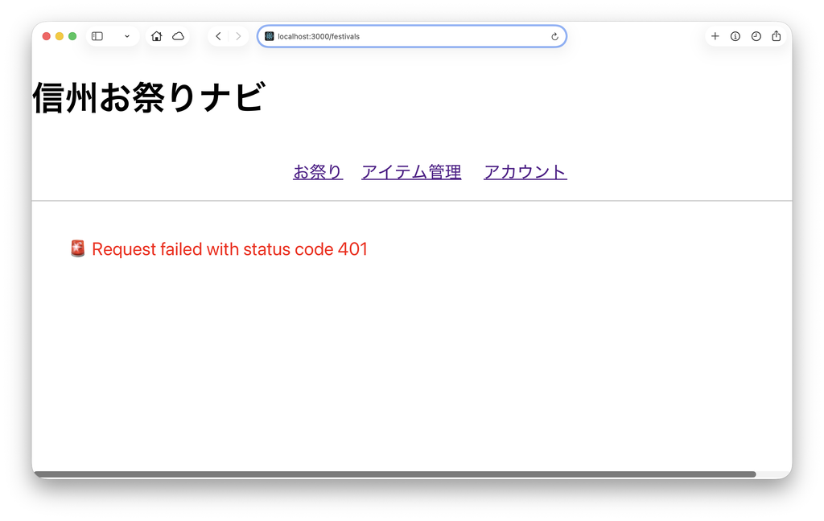

### アイテム管理ページ(/items)を管理者アカウントでしかアクセスできないようにする

- お祭りタブで発生している事象と一緒だが、そもそもお祭りの追加は管理者しか行わないため。